# ¿Dónde es mejor sembrar maíz según la temperatura en indiana?

[figure not shown]

¡Hola! Soy Simón

Estudiante de estadística, amante de los datos y de las matemáticas, entusiasta de la programación y de las buenas caminatas.

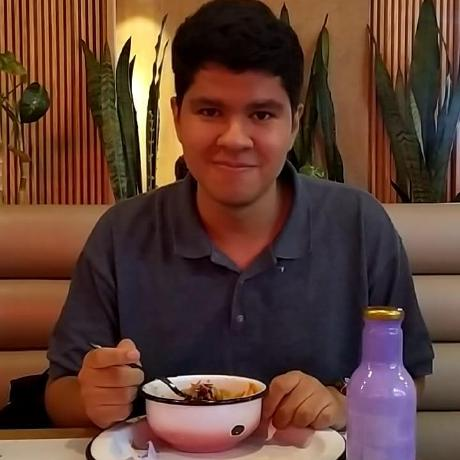

¡Hola! Soy Juan José

Estudiante de estadística, apasionado por el machine learning, aficionado a los deportes y a los videojuegos.

[figure not shown]

¡Hola! Soy Germán

Estudiante de estadística, apasionado por la analítica, las series de tiempo y la estadística espacial.

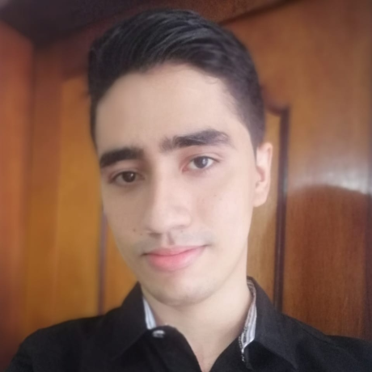

Repositorio de GitHub

Si quieres ver el código con el que fue ajustado el modelo y todo lo que hay detrás de él como la construcción de los datos, mallas de predicción, análisis descriptivo, entre otros, te invitamos a que visites el repositorio del proyecto. Da click al logo para más información y visita la carpeta Geoestadistica.

[figure not shown]

[figure not shown]

# ¿Dónde es mejor sembrar maíz según la temperatura en indiana?

# Contextualización

El invierno es feroz, más aún cuando de agricultura se trata. Indiana, estado precioso cuyo mayor costo de [producción agrícola](https://www.nass.usda.gov/Quick_Stats/Ag_Overview/stateOverview.php?state=INDIANA) se debe al cultivo de maíz.

Motivados por este hecho, se tomó la decisión de investigar cuáles son aquellas zonas en las que se presenta una mayor temperatura y una mayor irradiación por parte de la radiación que emite la luz solar, ya que el maíz es un vegetal que aprovecha mucho ambas características para su [crecimiento y desarrollo](https://www.pioneer.com/us/agronomy/soil_temp_corn_emergence.html#:~:text=Key%20Points,corn%20emergence%20and%20seedling%20health.).

# Temperatura e irradiación solar

Se miden las variables irradiación solar y temperatura en ubicaciones especificas del estado de indiana en estados unidos múltiples veces (90 en cada punto); dichas mediciones se realizan en ubicaciones igualmente espaciadas.

Teniendo en cuenta que se tienen múltiples mediciones de las variables surge la necesidad de resumir esta información con alguna métrica puesto que en la teoría vista se considera una única realización del proceso estocástico, a continuación se muestran los histogramas de las variables consideradas.

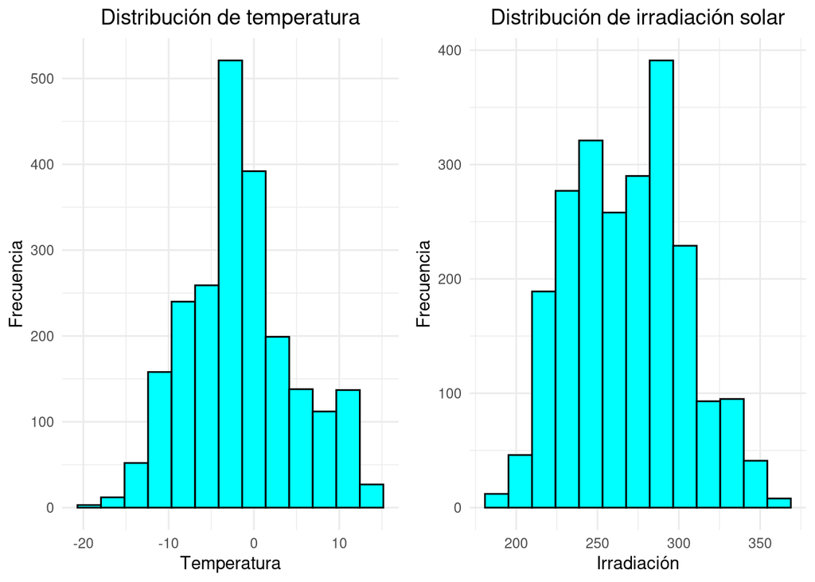

Dada la aparente simetría en los histogramas, simplificar las mediciones de dichas variables con sus respectivos promedios y medianas no es una idea descabellada.

# Base de datos definitiva

La base de datos definitiva se construye agrupando los datos por la longitud y latitud debido a que, como se mencionó previamente, se tienen múltiples mediciones de las variables en cada ubicación, los cuales corresponden a los primeros tres meses del año. Una vez agrupadas las ubicaciones, se promedia y se toma la mediana de todos los valores medidos en dichas ubicaciones de las variables de interés. La base de datos resultante tiene la siguiente estructura

Presentación de algunos datos

| Latitud | Longitud | Irradiación media | Irradiación mediana | Temperatura media | Temperatura mediana |
| --- | --- | --- | --- | --- | --- |
| 39.25 | -87.25 | 271.5758 | 271.955 | -0.3102222 | -0.975 |
| 39.25 | -86.75 | 272.1200 | 271.625 | -0.3174444 | -0.885 |
| 39.25 | -86.25 | 272.1200 | 271.625 | -0.3833333 | -0.890 |
| 39.25 | -85.75 | 272.2951 | 271.685 | -0.4791111 | -1.030 |
| 39.25 | -85.25 | 272.2951 | 271.685 | -0.4662222 | -1.050 |

Para finalizar se muestra el mapa de las ubicaciones de muestreo.

[interactive chart not shown]

# Chequeo de autocorrelación espacial

A continuación se chequea rapidamente la autocorrelación espacial pues si esta no existiera cualquier tipo de análisis posterior carecería de sentido

## Argumento gráfico

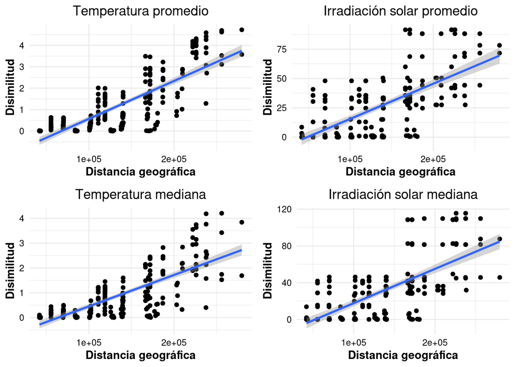

En todos los casos se puede observar una tendencia de asosiación entre la distancia geografica y las medidas de disimilitud lo cual sugiere la existencia de autocorrelación espacial para las variables temperatura e irradiación solar

## Pruebas de mantel para autocorrelación espacial

**Temperatura promedio**

```
##
## Mantel statistic based on Pearson's product-moment correlation
##
## Call:
## mantel(xdis = geodist, ydis = dist.temp)
##
## Mantel statistic r: 0.7739
##       Significance: 0.001
##
## Upper quantiles of permutations (null model):
##    90%    95%  97.5%    99%
## 0.0893 0.1202 0.1510 0.1898
## Permutation: free
## Number of permutations: 999
```

**Irradiación solar promedio**

```
##
## Mantel statistic based on Pearson's product-moment correlation
##
## Call:
## mantel(xdis = geodist, ydis = dist.irra)
##
## Mantel statistic r: 0.6614
##       Significance: 0.001
##
## Upper quantiles of permutations (null model):
##    90%    95%  97.5%    99%
## 0.0853 0.1230 0.1453 0.1821
## Permutation: free
## Number of permutations: 999
```

**Temperatura solar mediana**

```
##
## Mantel statistic based on Pearson's product-moment correlation
##
## Call:
## mantel(xdis = geodist, ydis = dist.temp.median)
##
## Mantel statistic r: 0.7368
##       Significance: 0.001
##
## Upper quantiles of permutations (null model):
##    90%    95%  97.5%    99%
## 0.0962 0.1277 0.1653 0.2129
## Permutation: free
## Number of permutations: 999
```

**Irradiación solar mediana**

```
##
## Mantel statistic based on Pearson's product-moment correlation
##
## Call:
## mantel(xdis = geodist, ydis = dist.irra.median)
##
## Mantel statistic r: 0.6524
##       Significance: 0.001
##
## Upper quantiles of permutations (null model):
##    90%    95%  97.5%    99%
## 0.0764 0.1087 0.1389 0.1760
## Permutation: free
## Number of permutations: 999
```

# Interpolación espacial

Dada la existencia de autocorrelación espacial, el siguiente paso es encontrar un modelo útil para realizar predicciones espaciales la región de interés, es decir, el estado de indiana.

## Semivariograma

A continuación se presenta el ajuste de semivariogramas tipo bin para las variables consideradas para 20 puntos usandos modelos gaussiano, exponencial y esférico respectivamente.

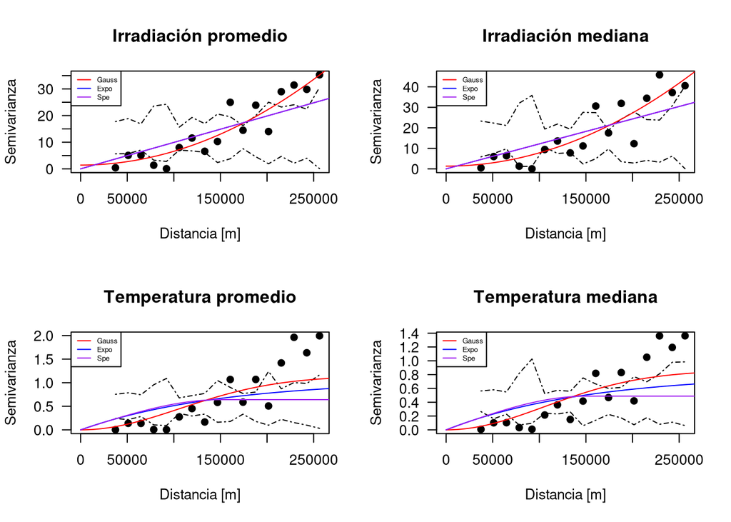

En primera instancia se destaca la autocorrelación espacial (que ya se habia verificado previamente) debido a que una considerable cantidad de puntos caen fuera de las bandas de confianza. Se puede apreciar que, en general, los puntos no están acotados lo cual es una señal de que la meseta es no finita y por la tanto se tendría estacionariedad intrínseca, por lo tanto es adecuado considerar modelos que puedan modelar tendencia en la media. Finalmente, se destaca que el modelo de semivarianza que mejor se ajusta es el gaussiano mientras que el esférico y exponencial presentan comportamientos similares.

## Kriging ordinario

Se realiza realiza el ajuste de kriging ordinario usando el método de mínimos cuadrados ordinarios. este tipo de kriging es el más sencillo y es usado en primera instancia para observar el comportamiento de las predicciones espaciales con los diferentes modelos de semivarianza.

### Irradiación promedio

#### Modelo gaussiano

##### Predicción

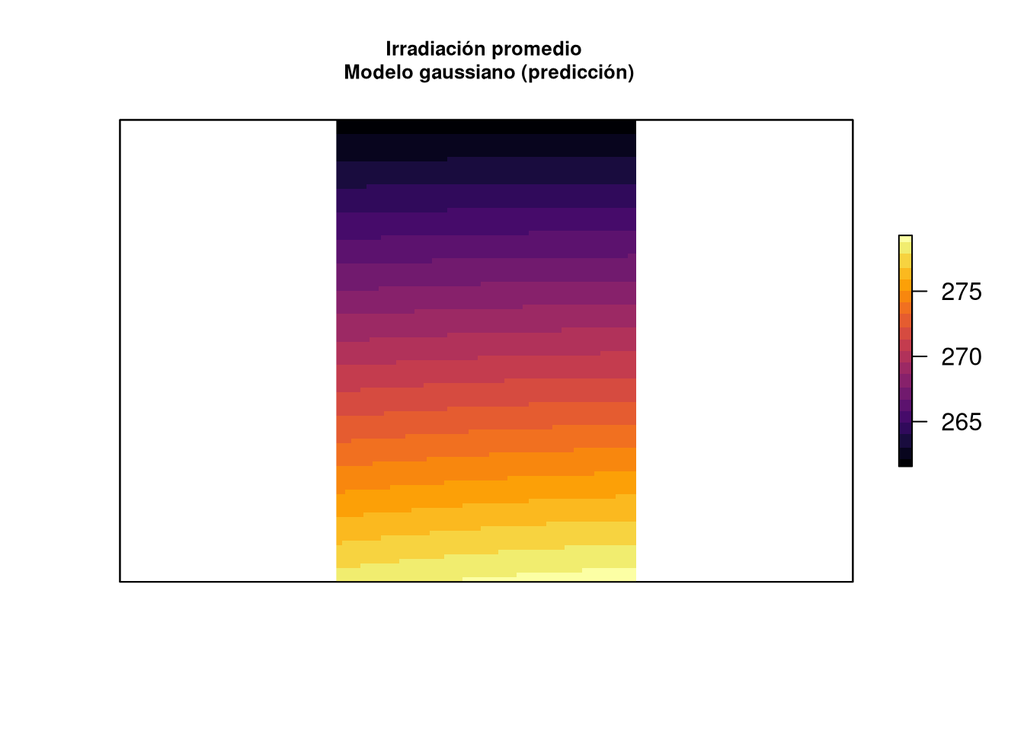

##### Desviación

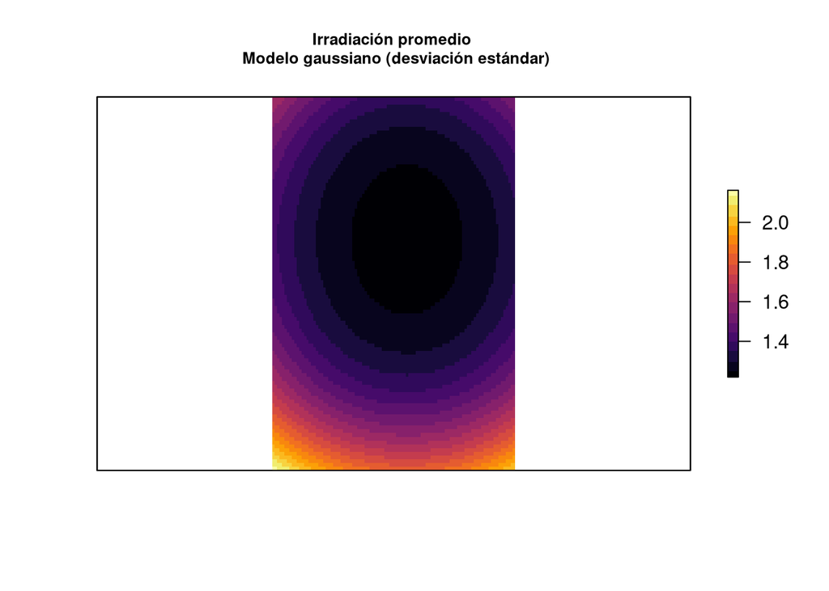

#### Modelo exponencial

##### Predicción

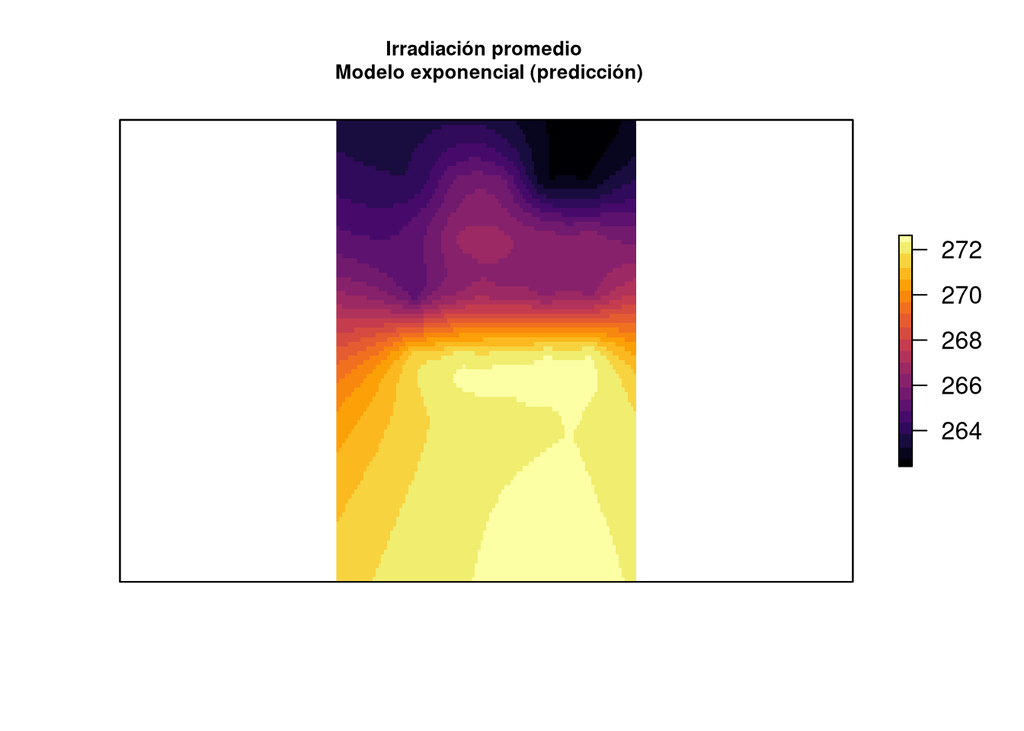

##### Desviación

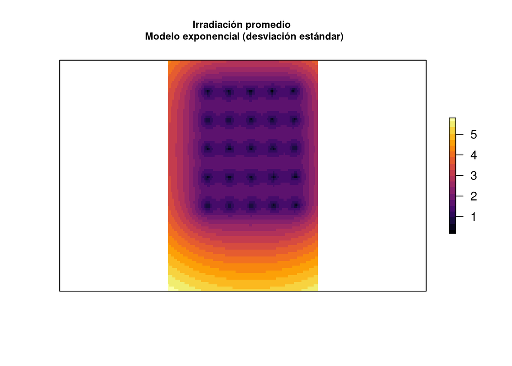

#### Modelo esférico

##### Predicción

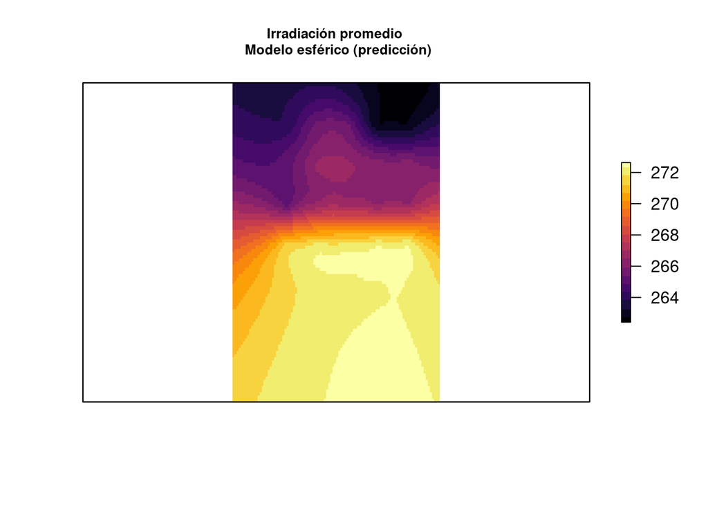

##### Desviación

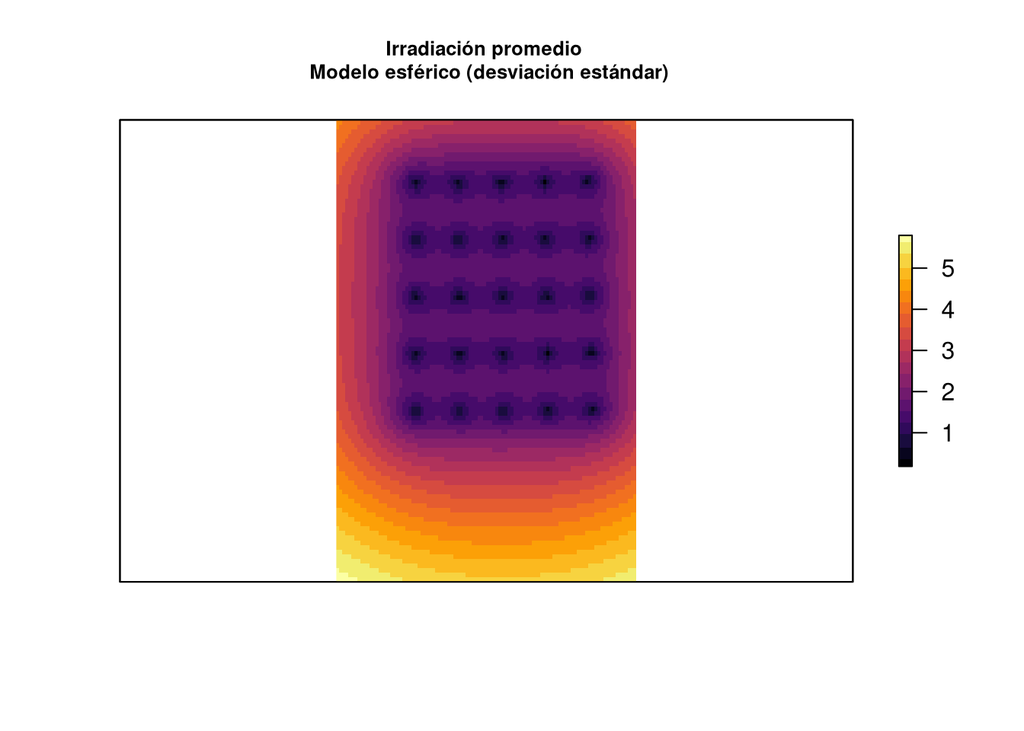

### Irradiación mediana

#### Modelo gaussiano

##### Predicción

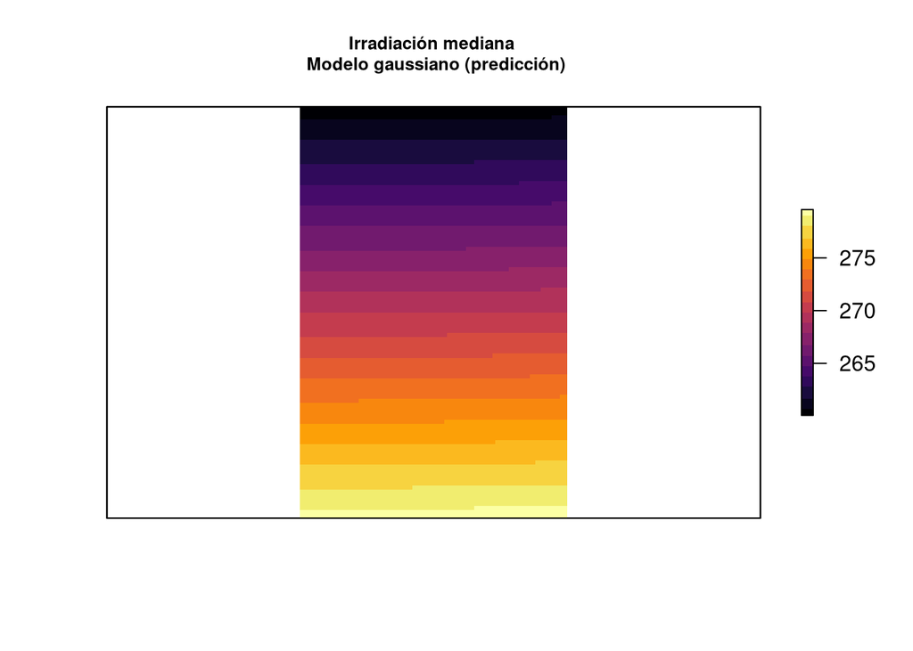

##### Desviación

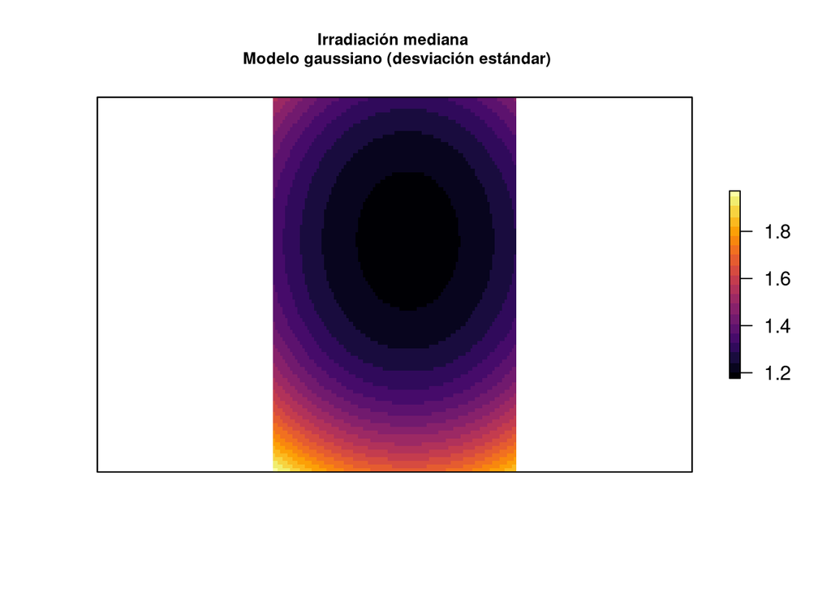

#### Modelo exponencial

##### Predicción

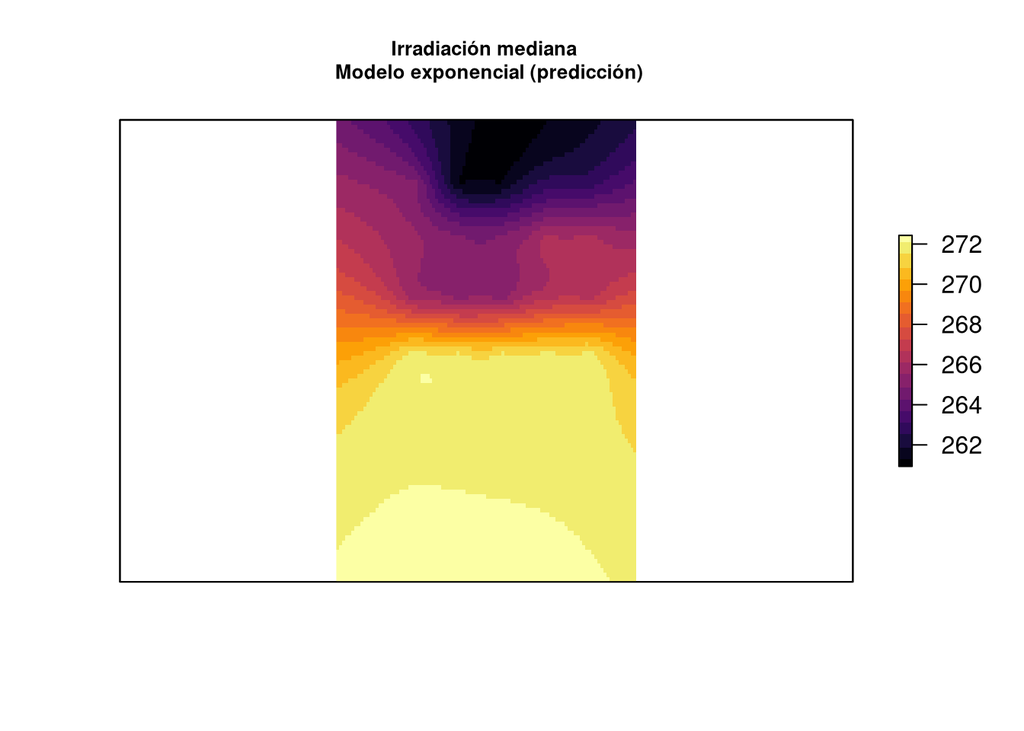

##### Desviación

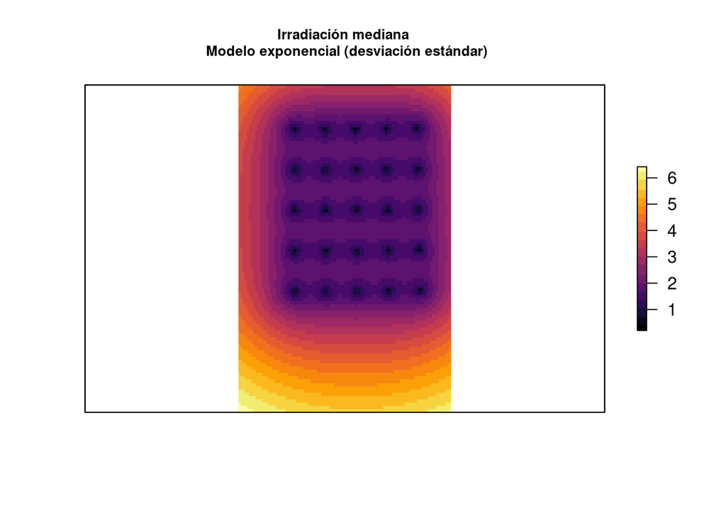

#### Modelo esférico

##### Predicción

[figure not shown]

##### Desviación

[figure not shown]

### Temperatura promedio

#### Modelo gaussiano

##### Predicción

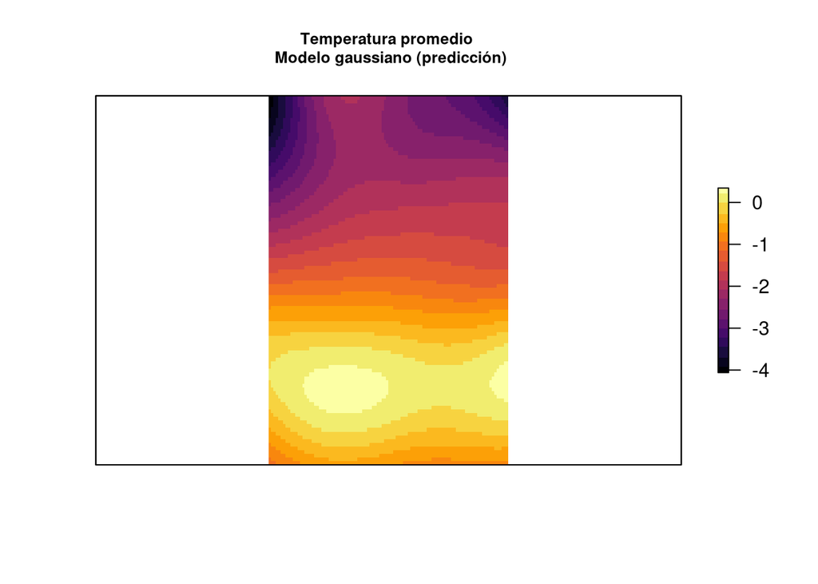

[output not shown]

[figure not shown]

##### Desviación

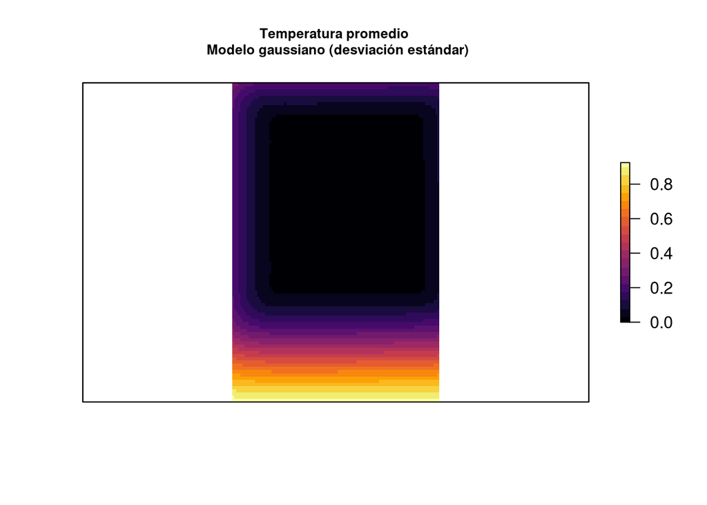

#### Modelo exponencial

##### Predicción

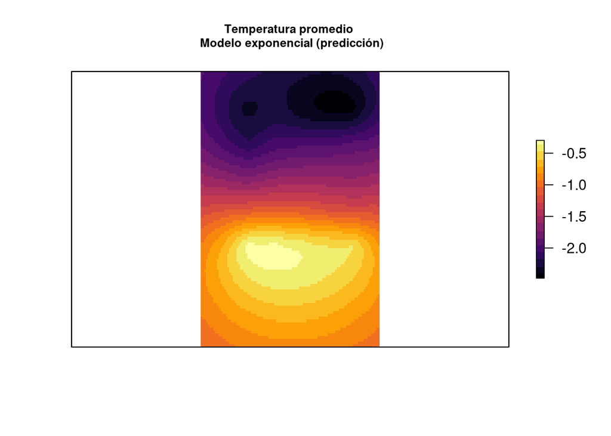

##### Desviación

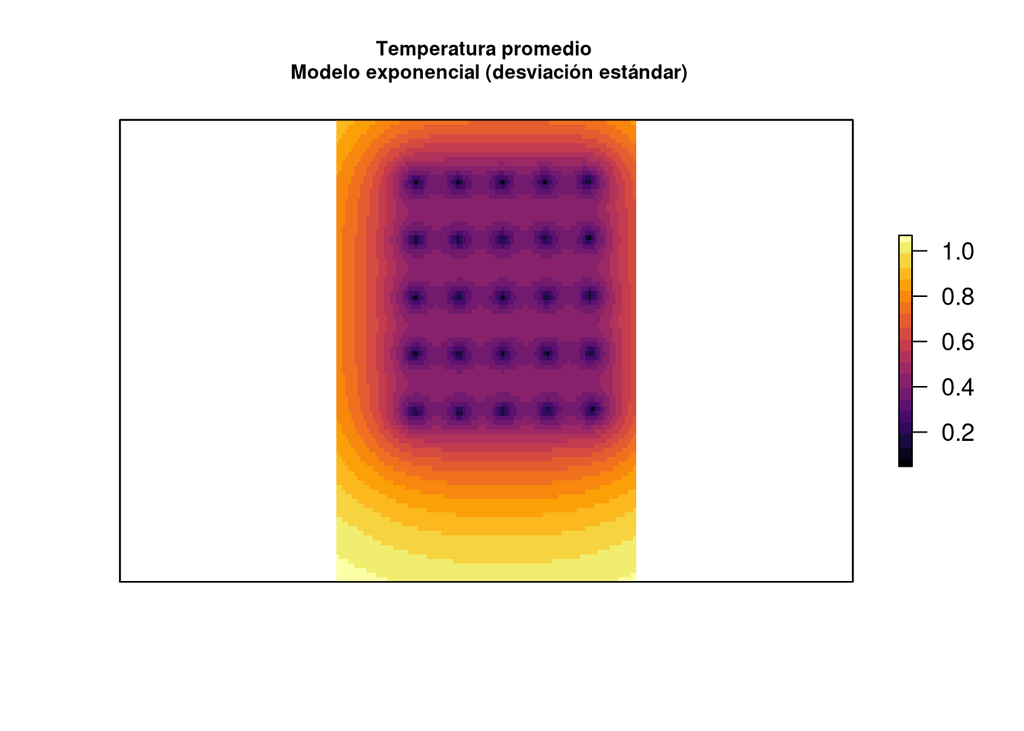

#### Modelo esférico

##### Predicción

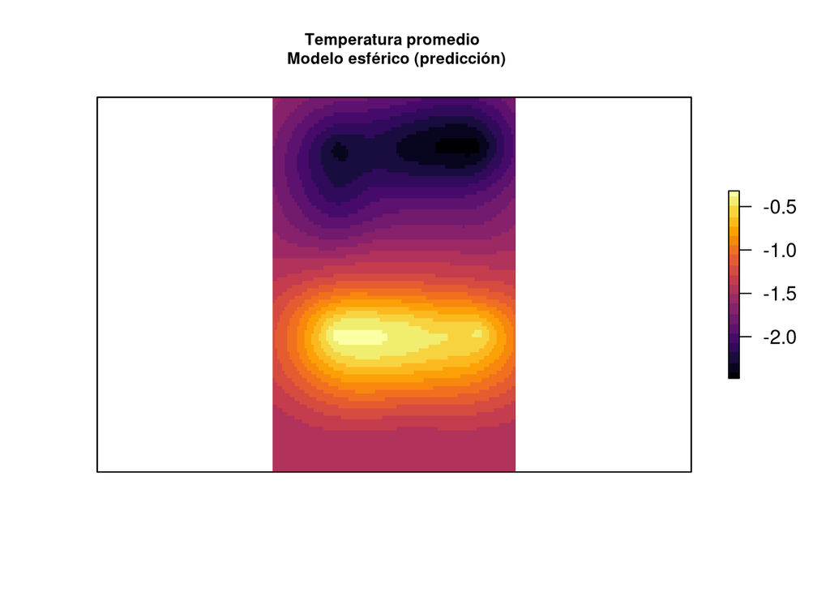

##### Desviación

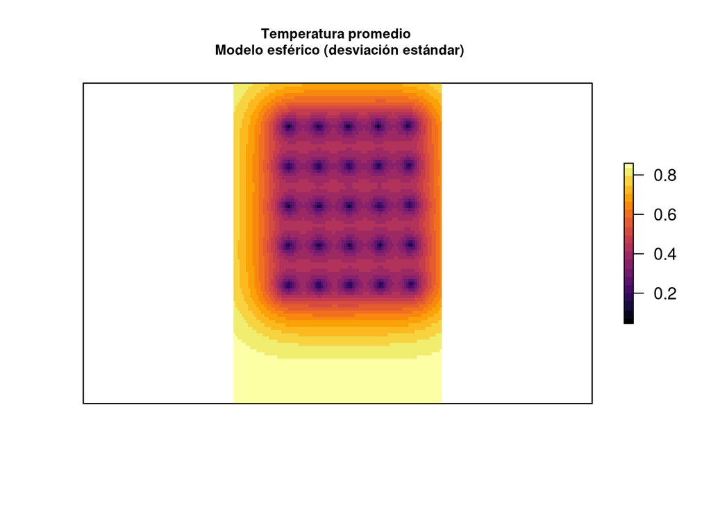

### Temperatura mediana

#### Modelo gaussiano

##### Predicción

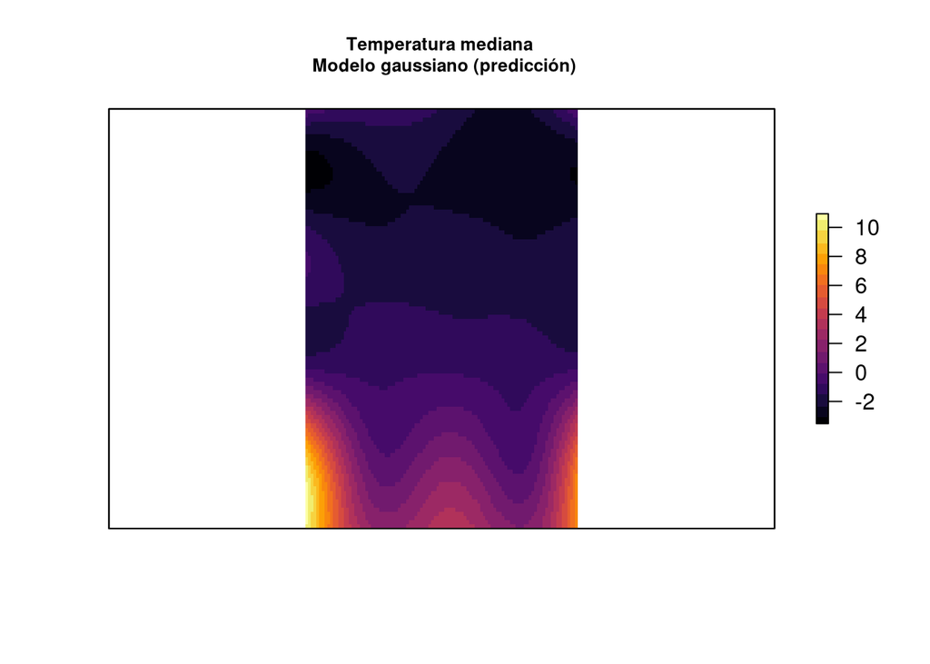

##### Desviación

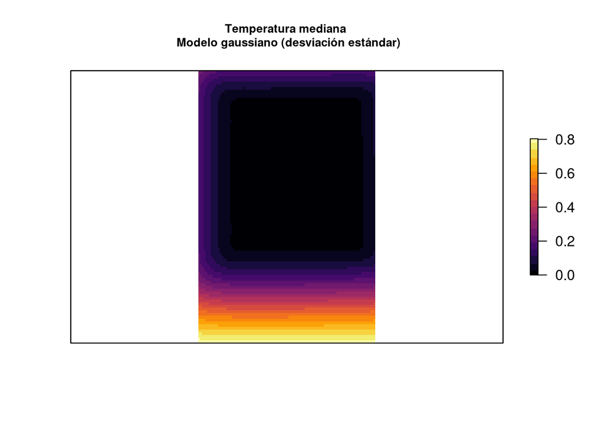

#### Modelo exponencial

##### Predicción

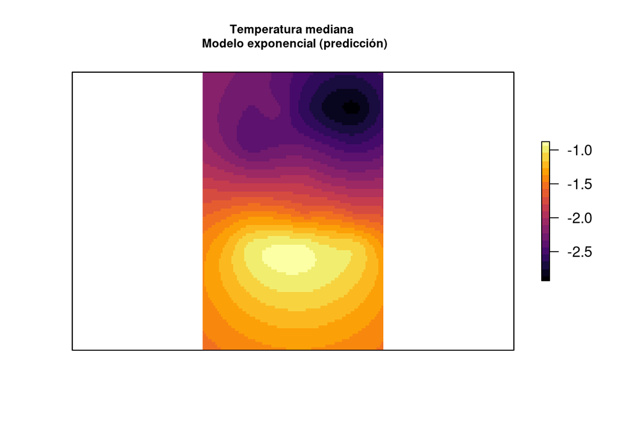

##### Desviación

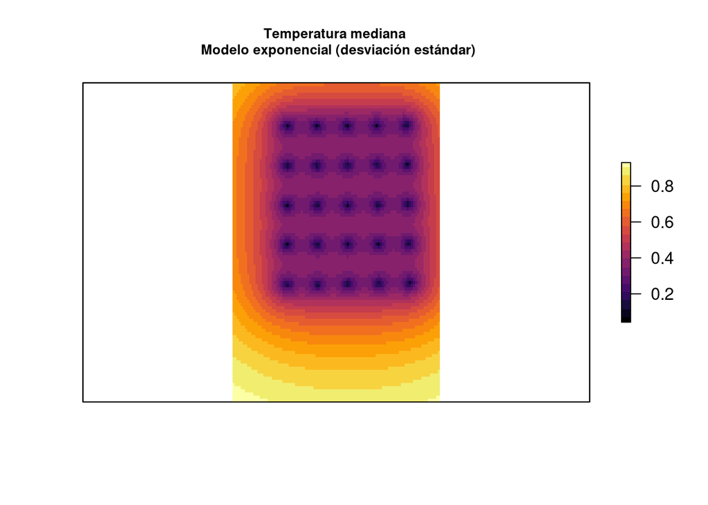

#### Modelo esférico

##### Predicción

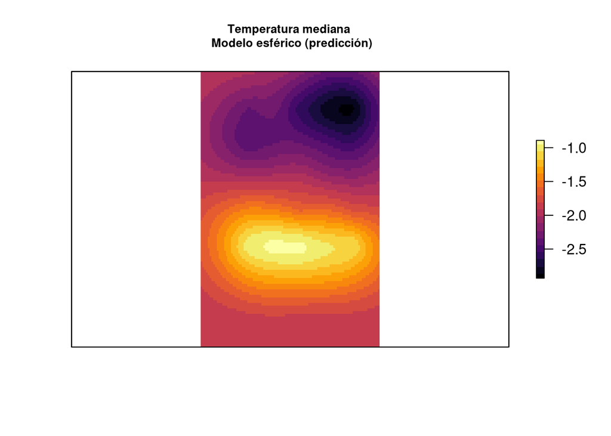

##### Desviación

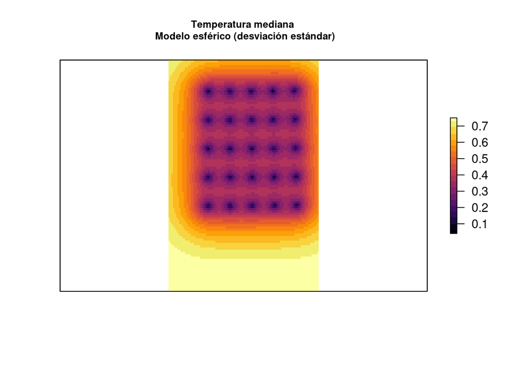

Luego de ajustar todos los modelos y realizar las respectivas predicciones se ve una tendencia clara, los modelos exponencial y esféricos tienen comportamientos muy similares en las predicciones realizadas y no son muy adecuados puesto que los valores de las desviaciones estándar de predicción son muy bajos cerca de los puntos de muestreo pero en ubicaciones un ligeramente distantes de estas dichos valores aumentan sustancialmente, sugiriendo que dichos modelos sobreajustan los datos. Por otro lado, los modelos gaussianos constrastan totalmente con el exponencial y esferico pues las desviaciones estándar se mantienen bajas en la gran mayoría de ventana de predicción sugiriendo una buena capacidad de generalizar la tendencia.